# 주제 : 시군구 성별, 연령별 주요 정신질환 통계 (2018~2022)

#### URL : https://www.data.go.kr/data/15118810/fileData.do

### 우리 주변에서도 정신 질환을 앓고 있는 사람을 의외로 주변에서 흔치 않게 볼 수 있다. 2018년부터 2022년까지의 건강보험심사평가원의 시군구별 주요 정신질환 통계를 분석하여 년도별 환자수와 증상별 환자수, 그리고 연령대 별 입원일수까지 계산하였다.

```python
import pandas as pd
import numpy as np
import matplotlib.pyplot as plt

plt.rcParams['axes.unicode_minus']=False
plt.rcParams["lines.linewidth"]=1
plt.rcParams['font.family']='Malgun Gothic'

file_path = './data/시군구 성별 연령별 주요 정신질환 통계 (2018~2022).csv'
df = pd.read_csv(file_path, encoding='cp949')

df.head(44)
```

|  | 진료년도 | 상별구분 | 시도 | 시군구 | 성별 | 연령구분 | 환자수 | 입내원일수 | 요양급여비용 |
| --- | --- | --- | --- | --- | --- | --- | --- | --- | --- |
| 0 | 2018 | ADHD | 서울 | 강남구 | 남 | 0~9세 | 437 | 3330 | 188836790 |
| 1 | 2018 | ADHD | 서울 | 강남구 | 남 | 10~19세 | 1111 | 8869 | 563498480 |
| 2 | 2018 | ADHD | 서울 | 강남구 | 남 | 20~29세 | 456 | 3485 | 213248290 |
| 3 | 2018 | ADHD | 서울 | 강남구 | 남 | 30~39세 | 174 | 1357 | 72761750 |
| 4 | 2018 | ADHD | 서울 | 강남구 | 남 | 40~49세 | 55 | 357 | 21611080 |
| 5 | 2018 | ADHD | 서울 | 강남구 | 남 | 50~59세 | 20 | 131 | 8719580 |
| 6 | 2018 | ADHD | 서울 | 강남구 | 남 | 60~69세 | 0 | 0 | 0 |
| 7 | 2018 | ADHD | 서울 | 강남구 | 남 | 70~79세 | 0 | 0 | 0 |
| 8 | 2018 | ADHD | 서울 | 강남구 | 남 | 80~89세 | 0 | 0 | 0 |
| 9 | 2018 | ADHD | 서울 | 강남구 | 남 | 90~99세 | 0 | 0 | 0 |
| 10 | 2018 | ADHD | 서울 | 강남구 | 남 | 100세 이상 | 0 | 0 | 0 |
| 11 | 2018 | ADHD | 서울 | 강남구 | 여 | 0~9세 | 95 | 671 | 40611900 |
| 12 | 2018 | ADHD | 서울 | 강남구 | 여 | 10~19세 | 327 | 2437 | 150243440 |
| 13 | 2018 | ADHD | 서울 | 강남구 | 여 | 20~29세 | 268 | 1788 | 107614200 |
| 14 | 2018 | ADHD | 서울 | 강남구 | 여 | 30~39세 | 104 | 638 | 37167510 |
| 15 | 2018 | ADHD | 서울 | 강남구 | 여 | 40~49세 | 31 | 150 | 8989670 |
| 16 | 2018 | ADHD | 서울 | 강남구 | 여 | 50~59세 | 0 | 0 | 0 |
| 17 | 2018 | ADHD | 서울 | 강남구 | 여 | 60~69세 | 0 | 0 | 0 |
| 18 | 2018 | ADHD | 서울 | 강남구 | 여 | 70~79세 | 0 | 0 | 0 |
| 19 | 2018 | ADHD | 서울 | 강남구 | 여 | 80~89세 | 0 | 0 | 0 |
| 20 | 2018 | ADHD | 서울 | 강남구 | 여 | 90~99세 | 0 | 0 | 0 |
| 21 | 2018 | ADHD | 서울 | 강남구 | 여 | 100세 이상 | 0 | 0 | 0 |
| 22 | 2018 | ADHD | 서울 | 강동구 | 남 | 0~9세 | 242 | 3322 | 139324590 |
| 23 | 2018 | ADHD | 서울 | 강동구 | 남 | 10~19세 | 375 | 4620 | 224332400 |
| 24 | 2018 | ADHD | 서울 | 강동구 | 남 | 20~29세 | 53 | 384 | 17327480 |
| 25 | 2018 | ADHD | 서울 | 강동구 | 남 | 30~39세 | 20 | 213 | 11352370 |
| 26 | 2018 | ADHD | 서울 | 강동구 | 남 | 40~49세 | 10 | 130 | 6790300 |
| 27 | 2018 | ADHD | 서울 | 강동구 | 남 | 50~59세 | 0 | 0 | 0 |
| 28 | 2018 | ADHD | 서울 | 강동구 | 남 | 60~69세 | 0 | 0 | 0 |
| 29 | 2018 | ADHD | 서울 | 강동구 | 남 | 70~79세 | 0 | 0 | 0 |
| 30 | 2018 | ADHD | 서울 | 강동구 | 남 | 80~89세 | 0 | 0 | 0 |
| 31 | 2018 | ADHD | 서울 | 강동구 | 남 | 90~99세 | 0 | 0 | 0 |
| 32 | 2018 | ADHD | 서울 | 강동구 | 남 | 100세 이상 | 0 | 0 | 0 |
| 33 | 2018 | ADHD | 서울 | 강동구 | 여 | 0~9세 | 59 | 579 | 24519500 |
| 34 | 2018 | ADHD | 서울 | 강동구 | 여 | 10~19세 | 108 | 1219 | 53047390 |
| 35 | 2018 | ADHD | 서울 | 강동구 | 여 | 20~29세 | 30 | 216 | 11086910 |
| 36 | 2018 | ADHD | 서울 | 강동구 | 여 | 30~39세 | 21 | 192 | 9504150 |
| 37 | 2018 | ADHD | 서울 | 강동구 | 여 | 40~49세 | 0 | 0 | 0 |
| 38 | 2018 | ADHD | 서울 | 강동구 | 여 | 50~59세 | 0 | 0 | 0 |
| 39 | 2018 | ADHD | 서울 | 강동구 | 여 | 60~69세 | 0 | 0 | 0 |
| 40 | 2018 | ADHD | 서울 | 강동구 | 여 | 70~79세 | 0 | 0 | 0 |
| 41 | 2018 | ADHD | 서울 | 강동구 | 여 | 80~89세 | 0 | 0 | 0 |
| 42 | 2018 | ADHD | 서울 | 강동구 | 여 | 90~99세 | 0 | 0 | 0 |
| 43 | 2018 | ADHD | 서울 | 강동구 | 여 | 100세 이상 | 0 | 0 | 0 |

#### 데이터에 있던 정신질환으로는 ADHD(주의력 결핍 과잉행동 장애), 불면증, 불안장애, 우울증, 조울증, 조현병이 있다. 지역(구)별로 정신질환을 앓고 있는 사람들의 분포도를 계산한다.

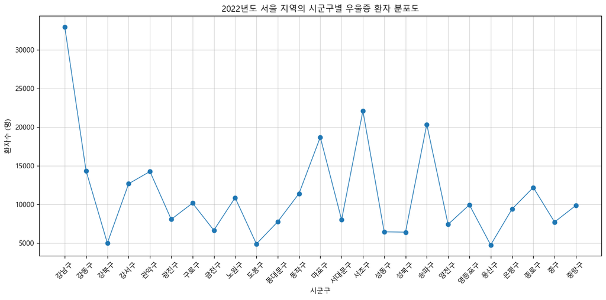

```python
def plot_patient_distribution(data, year, disorder, region):

    filtered_data = data[(data['진료년도'] == int(year)) & (data['상별구분'] == disorder) & (data['시도'] == region)]

    grouped_data = filtered_data.groupby('시군구')['환자수'].sum().reset_index()

    plt.figure(figsize=(12, 6))
    plt.plot(grouped_data['시군구'], grouped_data['환자수'], marker='o')
    plt.title(f'{year}년도 {region} 지역의 시군구별 {disorder} 환자 분포도')
    plt.xlabel('시군구')
    plt.ylabel('환자수 (명)')
    plt.xticks(rotation=45)
    plt.grid(True, alpha=0.5)
    plt.tight_layout()
    plt.show()

plot_patient_distribution(df, "2022", "우울증", "서울")
```

#### 위 결과로는 환자 수가 가장 많은 지역은 강남구, 두 번째로는 서초구, 세 번째로는 송파구 라는 결과가 나왔다. 처음에는 환자 수는 곧 자치구의 인구 수에 비례한 값이 나올 것이라는 생각을 하였는데, 정작 인구수가 가장 많은 자치구는 송파구였고 압도적으로 환자 수가 많은 강남구 같은 경우는 서울시 25개의 자치구 중 3번째(송파구, 강서구 다음)에 위치해있었다. 두 번째인 서초구는 서울시 자치구 중 10번째로 인구 수가 많다. 자료는 병원에서 실제 진료를 받은 사람을 대상으로 통계를 내린 것이기 때문에 정신과 진료를 거부한 환자까지 포함한다면 환자 수는 더욱 많아질 것이다.

#### 원인을 분석하자면 일단 강남, 서초, 송파 전부 상대적으로 경제적 생활 수준이 높기로 평가되는 지역들이다. 이 지역들에서는 라이프스타일이 비교적 빠르고 경쟁이 치열하다. 일부 사람들은 이러한 환경에서 오는 경제적, 사회적 압박, 업무 스트레스 등으로 우울증과 같은 정신 질환을 가질 수 있다. 또한 이 세 지역은 서울시에서 의료 인프라 및 전문 의료 서비스에 접근하기 쉬운 지역이다. 이와 관련하여 경제적 여유가 있는 만큼 정신과 치료에 대한 거부감도 적은 것으로 생각된다.

#### 마지막으로 강남구가 다른 지역들에 비해 압도적으로 환자수가 많은 이유를 분석해보자면, 청소년과 청년(20~30대) 환자가 전 연령 통틀어 가장 많은 환자수 비율을 보유하고 있다. 10대의 경우에는 학업 스트레스로 인해 우울증을 호소하는 환자들이 많다. 전국 상위권 고등학교와 대형 (입시)학원이 밀집해 있는 만큼 강남구는 학업 경쟁이 가장 치열한 지역으로, 시험에 대한 불안감과 부모의 압박으로 인해 우울증을 호소하는 10대 환자가 많은 것으로 보인다. 20~30대 청년층은 취업난으로 인한 스트레스와 결혼 등 미래에 대한 불안감으로 인해 우울증을 호소하는 환자들이 많아지고 있는 것으로 보인다. 또한 현 20대~30대 세대(흔히 말하는 MZ 세대)부터는 부모보다 더 못 살게 되는 첫 세대라고 불리고 있고, 사회 환경이 급변하여 이에 적응하지 못하고 점차 심해지는 취업난으로 스트레스가 더욱 더 가중되고 있다고 생각한다.

### 2. 연도별 정신질환별 환자 수 총합

#### 매년 인구수는 감소하고 있는 반면에 정신질환으로 인해 병원을 찾는 사람들은 날이 갈수록 늘어나고 있다. 이에 대해 각각 질환에 대한 원인을 분석해보려고 한다.

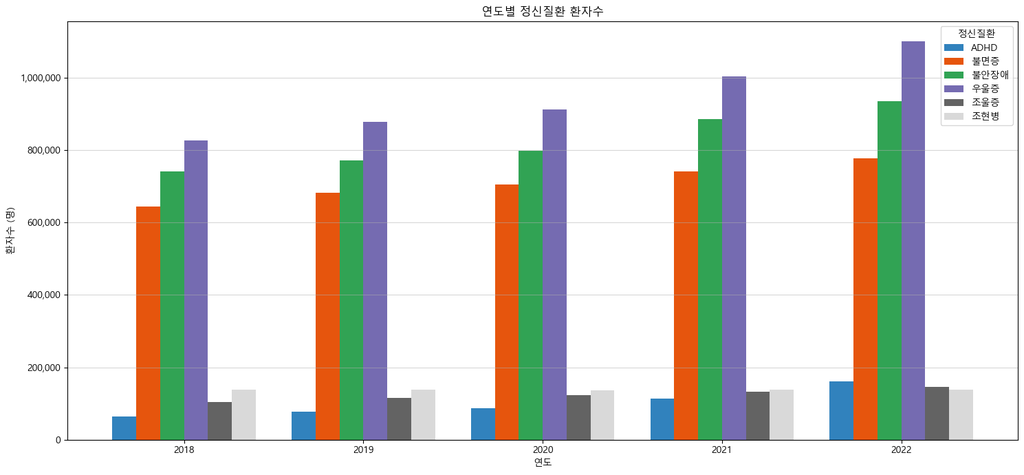

```python
def plot_total_patients_by_disorder(datas):
    grouped_data = datas.groupby(['진료년도', '상별구분'])['환자수'].sum().unstack()

    grouped_data.plot(kind='bar', figsize=(15, 7), width=0.8, colormap='tab20c')
    ax = plt.gca()
    plt.title('연도별 정신질환 환자수')
    plt.xlabel('연도')
    plt.ylabel('환자수 (명)')
    plt.xticks(rotation=0)

    current_values = plt.gca().get_yticks()
    ax.yaxis.set_major_locator(plt.FixedLocator(current_values))
    ax.set_yticklabels(['{:,.0f}'.format(x) for x in current_values])

    plt.grid(axis='y', alpha=0.5)
    plt.legend(title='정신질환')
    plt.tight_layout()
    plt.show()

plot_total_patients_by_disorder(df)
```

### 3. 연령대 별 정신질환 환자의 입내원일수 추이 (2018~2022)

#### 상해나 손상 등의 신체적 외상으로 인한 입내원이 아닌 정신질환으로 입내원하는 환자도 많아지고 있다. 아래 그래프는 각 연령대 별 입내원환자의 일수 총합을 나타낸다.

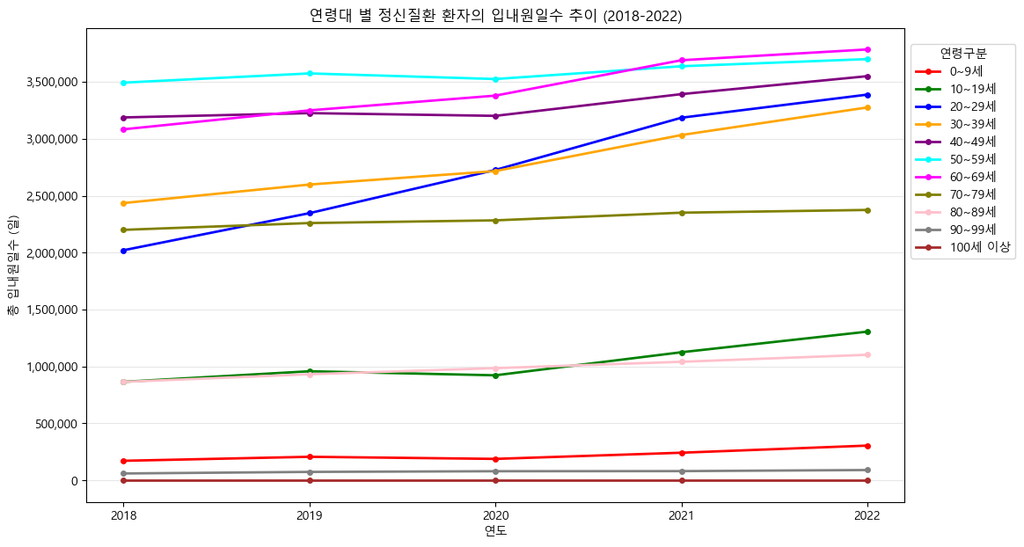

```python
def plot_inpatient_outpatient_days(data):
    grouped_data = data.groupby(['진료년도', '연령구분'])['입내원일수'].sum().reset_index()

    pivot_data = grouped_data.pivot(index='진료년도', columns='연령구분', values='입내원일수')

    age_groups_ordered = ['0~9세', '10~19세', '20~29세', '30~39세', '40~49세',
                      '50~59세', '60~69세', '70~79세', '80~89세', '90~99세', '100세 이상']

    for age_group in age_groups_ordered:
        if age_group not in pivot_data.columns:
            pivot_data[age_group] = 0

    css_colors = [
        "red", "green", "blue", "orange", "purple",
        "cyan", "magenta", "olive", "pink", "gray", "brown"
    ]

    plt.figure(figsize=(12, 7))
    for i, age_group in enumerate(age_groups_ordered):
        plt.plot(pivot_data.index, pivot_data[age_group], label=age_group,
                 marker='o', markersize=4, linewidth=2, color=css_colors[i])

    ax = plt.gca()
    plt.title('연령대 별 정신질환 환자의 입내원일수 추이 (2018-2022)')
    plt.xlabel('연도')
    plt.ylabel('총 입내원일수 (일)')
    current_values = ax.get_yticks()
    ax.yaxis.set_major_locator(plt.FixedLocator(current_values))
    ax.set_yticklabels(['{:,.0f}'.format(x) for x in current_values])
    plt.xticks(pivot_data.index)
    plt.legend(title='연령구분', loc='lower left', bbox_to_anchor=(1.0, 0.5))
    plt.grid(axis='y', alpha=0.3)
    plt.show()

plot_inpatient_outpatient_days(df)
```

#### 우선 입내원일수 값과 폭이 상당히 낮은 90~99세, 100세 이상 계열은 당연하게도 타 연령층에 비해 인구수가 압도적으로 낮다. 그렇기에 상승 하락폭이 거의 없다(100세 이상은 입내원일수 데이터가 아예 존재하지 않았다). 입내원일수가 가장 많은 연령층은 중년층(40대~60대)으로 나타났으며, 다음 연령층인 70대 이후는 중년층에 비해 조울증, 조현병 환자가 많이 줄어들었다. 원인으로는 낮은 인구 계층도 있지만 많은 나이로 인해 조증의 증상이 대폭 감소되었다. 20대와 30대(MZ세대)는 우울증에 언급된 내용처럼 취업난으로 인한 스트레스와 미래에 대한 불안감, 사회 환경 급변으로 인해 정신질환 환자수가 크게 늘어나고 있고 그에 따른 입내원일수 역시 눈에 띄게 큰 상승폭을 보여주고 있다.